# 2 Introduction to Research Methodology

## 2.1 Research Methodology

> *Research methodology* deals with how to conduct a scientific study. As an academic course, it discusses all the theories, methods and procedures that are required to carry out a research work.

| **Research methodology** > | > **Research method** > | > **Research design** > | > **Experimental design** |
| --- | --- | --- | --- |
| Research methodology deals with how to conduct a scientific study. As an academic course, it discusses all the theories, methods and procedures that are required to carry out a research work. | Research methods typically include study location, population, sampling, research design, experimental design, variables, data collection tools, and analytical procedures. | Research approach (qualitative, quantitative, mixed) that also includes experimental design. | The intended settings of experimental units, treatment application, randomization, data collection period. |
| This provides necessary explanations of choosing a particular location and methods for a specific research work. | Research method is a part of research methodology. | Research design is a part of research methods. | Experimental design is a part of research design. |

## 2.2 Knowledge, Science, Technology, Research

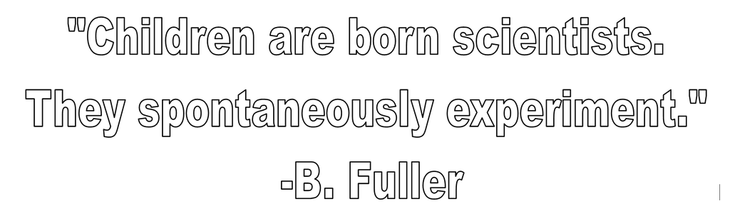

Knowledge is the stored information in our brain, books or internet that can be recalled when needed. If we cannot recall or retrieve the information that is not considered as knowledge. Knowledge can be gathered randomly from anywhere and by any means. However, if the knowledge is generated using systematic process (problem identification, data collection, analysis and interpretation) then this systematic knowledge is called science. Science is seen through its invention (device - pen, idea - planting date, or practice - row planting), which is called technology. When a technology is perceived as being new to an individual, the technology is termed as innovation (new technology).

**Research** is the process of generating the knowledge, i.e. the systematic process by which knowledge or technology is generated, in other words, a problem is solved. This process has to be reproducible. It is a systematic progress from the known to the unknown. Research is a crucial tool for making adjustment to the ever changing situation of our universe.